# Zadanie domowe nr 5

Aleksandra Gacek

20/11/2018

# Zadanie

Celem zadania było przeprowadzenie eksperymentu sprawdzającego istnienie problemów z odczytywaniem danych znajdujących się na źle wykonanych wykresach. W ramach mojego eksperymentu zdecydowałam się przetestować poprawność odczytywania danych na wykresach liniowych 3D.

# Przygotowane wykresy

- Pierwszy wykres:

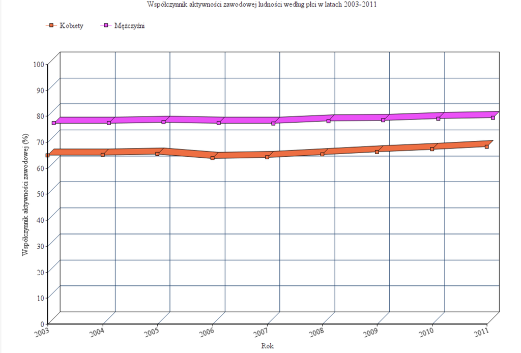

- Drugi wykres:

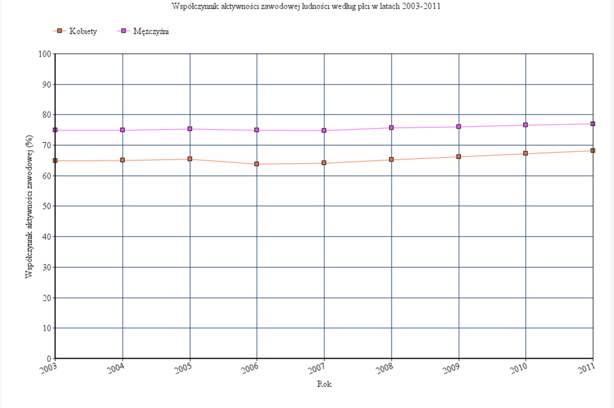

# Ankieta

Oba wykresy zamieściłam w ankiecie znajdującej się pod adresem: https://docs.google.com/forms/d/e/1FAIpQLSeiUlu7uZcOc5BPApdB-s9XYf5xVD5HBFGWc53Cer8ZH4v9Dw/viewform?usp=sf_link . Na podstawie każdego z wykresów użytkownicy mieli odpowiedzieć na 2 pytania jednokrotnego wyboru:

1. Ile wynosił współczynnik zatrudnienia wśród kobiet w 2006 roku?
- 60%
- 61%
- 63%
- 65%
2. O ile punktów procentowych różnił się współczynnik zatrudnienia kobiet i mężczyzn w 2007 roku?
- Około 5%
- Około 10%
- Około 13%
- Około 15%

Poprawna odpowiedź na pytanie 1 to 63%, na pytanie 2 to 10%.

# Wyniki

Ankietę przeprowadzono wśród 21 osób. Poniżej przedstawione są otrzymane wyniki.

## Pytanie 1

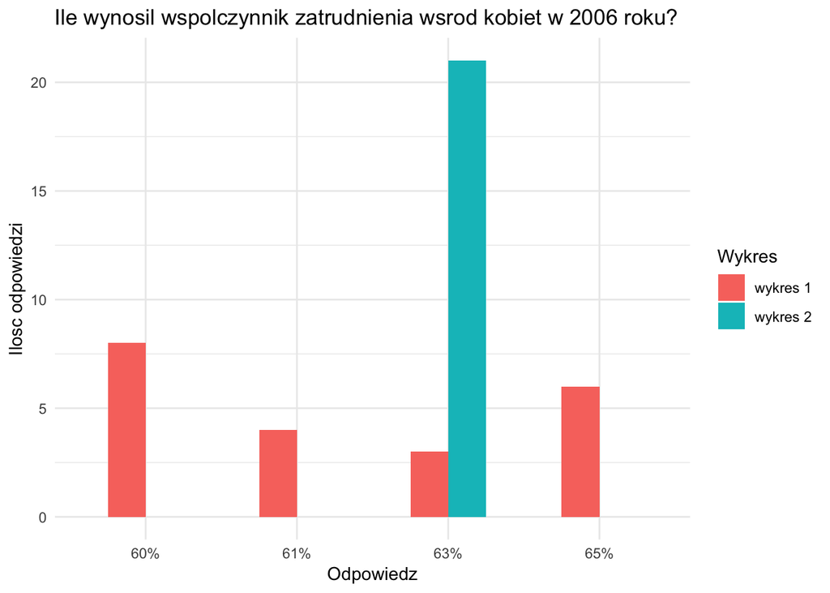

Jak możemy zauważyć na powyższym wykresie niewielu respondentów (3) wskazało poprawną odpowiedź na podstawie wykresu numer jeden, mimo iż widać zróżnicowanie w odpowiedziach. Właściwie każda inna odpowiedź uzyskała więcej głosów. Wręcz przeciwnie wygląda sytuacja w wypadku odpowiedzi na podstawie wykresu nr 2 (2D) - wszyscy respondenci udzielili prawidłowej odpowiedzi.

## Pytanie 2

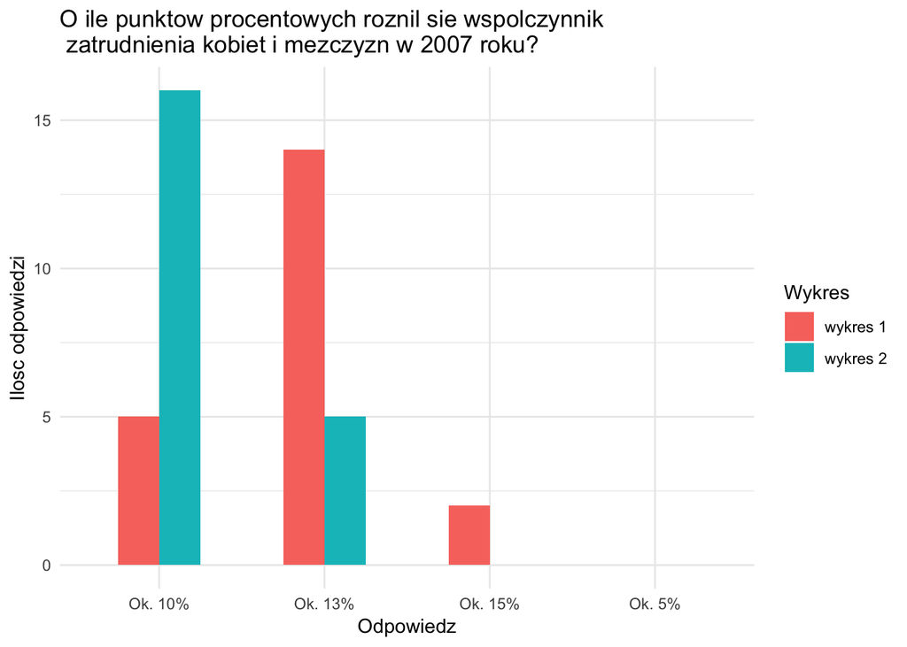

## Wnioski

Przeprowadzony eksperyment pokazał jak bardzo mylące są wykresy liniowe w perspektywie skośnej, z dodaniem sztucznego 3 wymiaru. Nawet niezbyt dobrze wykonany wykres 2D zdecydowanie mniej wprowadza użytkowników w błąd, są oni w stanie odczytać wynik. Większość uczestników ankiety miała problem z poprawnym odczytaniem wykresu w wersji 3D. Mimo, iż na pozór ten typ wykresu może się wydawać ciekawym zabiegiem artystycznym, to jednak w bardzo negatywny sposób wpływa na percepcje i odczyt danych. Cytując jednego z odpowiadających “ten pierwszy wykres to był beznadziejny”.